# EOCSI EASI training session 1: Introduction, datasets and xarray

## 1. Accessing data through EASI ODC API

View available products and data coverage at the EASI Explorer: https://explorer.asia.easi-eo.solutions

### Determine parameters for accessing data

#### Where and when?

e.g. Singapore, recent

#### What type of data?

reflectance, temperature, elevation?

#### What resolution and projection?

e.g.: 10 m resolution and epsg:32648 (UTM) (https://explorer.asia.easi-eo.solutions/product/s2_l2a/regions/48NUG)

or lat/lon and native grid for dataset

### Explore datasets through ODC API

A good example for Sentinel-2 https://github.com/csiro-easi/eocsi-hackathon-2022/blob/main/case-studies/Chlorophyll_monitoring.ipynb

```python
%matplotlib inline

import datacube
from datacube.utils import masking
import matplotlib
import matplotlib.pyplot as plt
import numpy as np
import pandas as pd
import xarray as xr

import warnings
warnings.filterwarnings("ignore")

import sys
sys.path.insert(1, '../Tools/')
from dea_tools.plotting import rgb, display_map
from dea_tools.bandindices import calculate_indices
```

```python
#import datacube

dc = datacube.Datacube(app="data_avail")
dc.list_products()
```

| name | name | description | license | default_crs | default_resolution |
| --- | --- | --- | --- | --- | --- |
| copernicus_dem_30 | copernicus_dem_30 | Copernicus 30m Digital Elevation Model (GLO-30) | None | None | None |
| landsat5_c2l2_sr | landsat5_c2l2_sr | Landsat 5 Collection 2 Level-2 Surface Reflect... | None | None | None |
| landsat5_c2l2_st | landsat5_c2l2_st | Landsat 5 Collection 2 Level-2 UTM Surface Tem... | CC-BY-4.0 | None | None |
| landsat7_c2l2_sr | landsat7_c2l2_sr | Landsat 7 USGS Collection 2 Surface Reflectanc... | None | None | None |
| landsat7_c2l2_st | landsat7_c2l2_st | Landsat 7 Collection 2 Level-2 UTM Surface Tem... | CC-BY-4.0 | None | None |
| landsat8_c2l1 | landsat8_c2l1 | Landsat 8 Collection 2 Level-1 (top of atmosph... | CC-BY-4.0 | None | None |
| landsat8_c2l2_sr | landsat8_c2l2_sr | Landsat 8 Collection 2 Surface Reflectance, pr... | None | None | None |
| landsat8_c2l2_st | landsat8_c2l2_st | Landsat 8 Collection 2 Level-2 UTM Surface Tem... | CC-BY-4.0 | None | None |
| landsat9_c2l1 | landsat9_c2l1 | Landsat 9 Collection 2 Level-1 (top of atmosph... | CC-BY-4.0 | None | None |
| landsat9_c2l2_sr | landsat9_c2l2_sr | Landsat 9 Collection 2 Surface Reflectance, pr... | CC-BY-4.0 | None | None |
| landsat9_c2l2_st | landsat9_c2l2_st | Landsat 9 Collection 2 Level-2 UTM Surface Tem... | CC-BY-4.0 | None | None |
| lpdaac_nasadem | lpdaac_nasadem | NASADEM Merged DEM Global 1 arc second V001 | None | None | None |
| nasa_aqua_l2_oc | nasa_aqua_l2_oc | NASA MODIS-Aqua L2 Ocean Color, regridded to W... | None | EPSG:4326 | (0.01, 0.01) |
| nasa_aqua_l2_sst | nasa_aqua_l2_sst | NASA MODIS-Aqua L2 Sea Surface Temperature, re... | None | EPSG:4326 | (0.01, 0.01) |
| s2_l2a | s2_l2a | Sentinel-2a and Sentinel-2b imagery, processed... | None | None | None |

```python
product = "s2_l2a"
```

```python
#dc.list_measurements().loc["nasa_aqua_l2_oc"]
dc.list_measurements().loc[product]
```

| measurement | name | dtype | units | nodata | aliases | flags_definition |
| --- | --- | --- | --- | --- | --- | --- |
| B01 | B01 | uint16 | 1 | 0 | [band_01, coastal_aerosol] | NaN |
| B02 | B02 | uint16 | 1 | 0 | [band_02, blue] | NaN |
| B03 | B03 | uint16 | 1 | 0 | [band_03, green] | NaN |
| B04 | B04 | uint16 | 1 | 0 | [band_04, red] | NaN |
| B05 | B05 | uint16 | 1 | 0 | [band_05, red_edge_1] | NaN |
| B06 | B06 | uint16 | 1 | 0 | [band_06, red_edge_2] | NaN |
| B07 | B07 | uint16 | 1 | 0 | [band_07, red_edge_3] | NaN |
| B08 | B08 | uint16 | 1 | 0 | [band_08, nir, nir_1] | NaN |
| B8A | B8A | uint16 | 1 | 0 | [band_8a, nir_narrow, nir_2] | NaN |
| B09 | B09 | uint16 | 1 | 0 | [band_09, water_vapour] | NaN |
| B11 | B11 | uint16 | 1 | 0 | [band_11, swir_1, swir_16] | NaN |
| B12 | B12 | uint16 | 1 | 0 | [band_12, swir_2, swir_22] | NaN |
| SCL | SCL | uint8 | 1 | 0 | [mask, qa] | {'qa': {'bits': [0, 1, 2, 3, 4, 5, 6, 7], 'val... |
| AOT | AOT | uint16 | 1 | 0 | [aerosol_optical_thickness] | NaN |
| WVP | WVP | uint16 | 1 | 0 | [scene_average_water_vapour] | NaN |

Useful figure for Sentinel-2 spectral bands: https://www.usgs.gov/faqs/how-does-data-sentinel-2as-multispectral-instrument-compare-landsat-data

```python
dc.list_measurements().loc[product].loc["SCL"]["flags_definition"]
```

```
{'qa': {'bits': [0, 1, 2, 3, 4, 5, 6, 7],
  'values': {'0': 'no data',
   '1': 'saturated or defective',
   '2': 'dark area pixels',
   '3': 'cloud shadows',
   '4': 'vegetation',
   '5': 'bare soils',
   '6': 'water',
   '7': 'unclassified',
   '8': 'cloud medium probability',
   '9': 'cloud high probability',
   '10': 'thin cirrus',
   '11': 'snow or ice'},
  'description': 'Sen2Cor Scene Classification'}}
```

### Load data

```python
# Define the area of interest
#latitude = (1.4300, 1.3950)
#longitude = (103.82300, 103.87000)

latitude = (-1.87, -1.85)
longitude = (120.51, 120.53)

time = ("2022")
display_map(x=longitude, y=latitude)
```

Make this Notebook Trusted to load map: File -> Trust Notebook

[interactive chart not shown]

```python
# Specify the parameters to pass to the load query
query = {
    "x": longitude,
    "y": latitude,
    "time": time,
    "group_by": "solar_day", #
    "cloud_cover": [0, 30], #
    "measurements": ["red", "green", "blue", "mask"], #
    "output_crs": "EPSG:32751", #
    "resolution": (-10, 10), #
    #"dask_chunks": {} #{"time": 1, "x":400, "y":400} #
}

# Load the data
ds_s2 = dc.load(product=product, **query)
```

```python
print(ds_s2)
```

```
<xarray.Dataset>
Dimensions:      (time: 4, y: 222, x: 223)
Coordinates:
  * time         (time) datetime64[ns] 2022-01-09T02:27:59 ... 2022-04-24T02:...
  * y            (y) float64 9.795e+06 9.795e+06 ... 9.793e+06 9.793e+06
  * x            (x) float64 2.23e+05 2.23e+05 2.23e+05 ... 2.252e+05 2.252e+05
    spatial_ref  int32 32751
Data variables:
    red          (time, y, x) uint16 783 667 522 503 535 ... 655 1010 545 590
    green        (time, y, x) uint16 899 782 667 652 698 ... 836 688 864 662 636
    blue         (time, y, x) uint16 627 599 481 469 493 ... 584 508 708 461 464
    mask         (time, y, x) uint8 7 7 10 10 10 10 10 10 10 ... 4 4 4 4 4 4 4 4
Attributes:
    crs:           EPSG:32751
    grid_mapping:  spatial_ref
```

### Plot data

Some plotting examples: https://github.com/GeoscienceAustralia/dea-notebooks/blob/develop/Beginners_guide/05_Plotting.ipynb

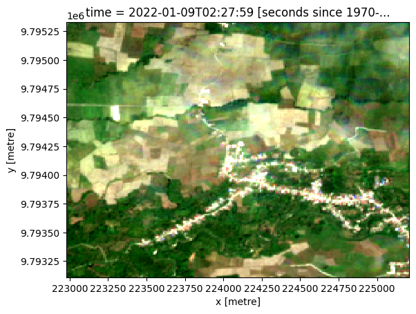

```python
ds_s2.isel(time=0)[["red","green","blue"]].to_array().plot.imshow(robust=True);
```

### Mask data

```python
masking.describe_variable_flags(ds_s2.mask)
```

|  | bits | values | description |
| --- | --- | --- | --- |
| qa | [0, 1, 2, 3, 4, 5, 6, 7] | {'0': 'no data', '1': 'saturated or defective'... | Sen2Cor Scene Classification |

```python
masking.describe_variable_flags(ds_s2.mask).loc["qa", "values"]
```

```
{'0': 'no data',
 '1': 'saturated or defective',
 '2': 'dark area pixels',
 '3': 'cloud shadows',
 '4': 'vegetation',
 '5': 'bare soils',
 '6': 'water',
 '7': 'unclassified',
 '8': 'cloud medium probability',
 '9': 'cloud high probability',
 '10': 'thin cirrus',
 '11': 'snow or ice'}
```

```python
# Multiple flags are combined as logial OR using the | symbol
cloud_free_mask = (
    masking.make_mask(ds_s2.mask, qa="vegetation") |
    masking.make_mask(ds_s2.mask, qa="bare soils") |
    masking.make_mask(ds_s2.mask, qa="water") |
    masking.make_mask(ds_s2.mask, qa="snow or ice")
)
```

```python
# Calculate proportion of good pixels
valid_pixel_proportion = cloud_free_mask.sum(dim=("x", "y"))/(cloud_free_mask.shape[1] * cloud_free_mask.shape[2])

valid_threshold = 0.5
observations_to_keep = (valid_pixel_proportion >= valid_threshold)
```

```python
# only keep observations above the good pixel proportion threshold
# The .compute() step means the values will be loaded into memory. This step may take some time
ds_s2 = ds_s2.sel(time=observations_to_keep)#.compute()
```

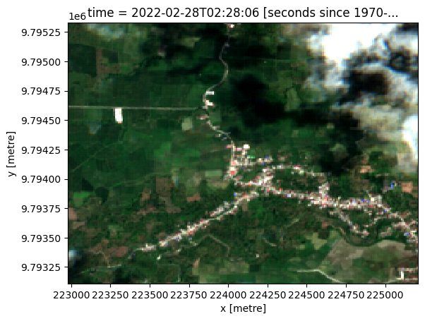

```python
ds_s2.isel(time=0)[["red","green","blue"]].to_array().plot.imshow(robust=True);
```

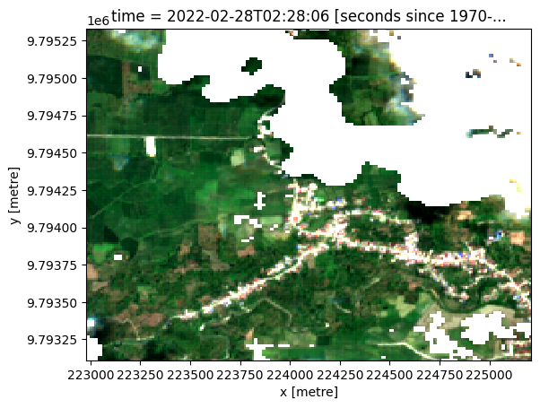

```python
# Mask the data
ds_s2_masked = ds_s2.where(cloud_free_mask)
ds_s2_masked.isel(time=0)[["red","green","blue"]].to_array().plot.imshow(robust=True);
```

```python
print(ds_s2)
```

```
<xarray.Dataset>
Dimensions:      (time: 3, y: 222, x: 223)
Coordinates:
  * time         (time) datetime64[ns] 2022-02-28T02:28:06 ... 2022-04-24T02:...
  * y            (y) float64 9.795e+06 9.795e+06 ... 9.793e+06 9.793e+06
  * x            (x) float64 2.23e+05 2.23e+05 2.23e+05 ... 2.252e+05 2.252e+05
    spatial_ref  int32 32751
Data variables:
    red          (time, y, x) uint16 350 335 375 435 452 ... 655 1010 545 590
    green        (time, y, x) uint16 544 579 547 636 586 ... 836 688 864 662 636
    blue         (time, y, x) uint16 362 366 379 391 399 ... 584 508 708 461 464
    mask         (time, y, x) uint8 4 4 4 4 4 4 4 4 4 4 ... 4 4 4 4 4 4 4 4 4 4
Attributes:
    crs:           EPSG:32751
    grid_mapping:  spatial_ref
```

## 2. Working with xarray

Resources from https://github.com/csiro-easi/eocsi-hackathon-2022/blob/main/01-welcome-to-easi.ipynb

Blog article on Xarray: https://towardsdatascience.com/basic-data-structures-of-xarray-80bab8094efa

Xarray documentation: http://xarray.pydata.org/en/stable/user-guide/data-structures.html

### Data structure

> Xarray allows us to work with **labeled multi-dimensional array**

A `Dataset` can be seen as a dictionary structure packing up the data, dimensions and attributes. Variables in a `Dataset` object are called `DataArrays` and they share dimensions with the higher level `Dataset`.

[figure not shown]

See also the terminology: https://docs.xarray.dev/en/stable/user-guide/terminology.html

- Data variables are stored as numpy or dask array
- Labels are in the forms of dimensions, coordinates and attributes
- xarray uses matplotlib for plotting
- ODC API (`datacube.load()`) loads data into a customized xarray dataset

See also an intro notebook (including how to construct a xarray dataset): https://github.com/GeoscienceAustralia/dea-notebooks/blob/develop/Beginners_guide/08_Intro_to_xarray.ipynb

And a more advanced notebook: https://rabernat.github.io/research_computing/xarray.html

```python
print(ds_s2)
```

```
<xarray.Dataset>
Dimensions:      (time: 3, y: 222, x: 223)
Coordinates:
  * time         (time) datetime64[ns] 2022-02-28T02:28:06 ... 2022-04-24T02:...
  * y            (y) float64 9.795e+06 9.795e+06 ... 9.793e+06 9.793e+06
  * x            (x) float64 2.23e+05 2.23e+05 2.23e+05 ... 2.252e+05 2.252e+05
    spatial_ref  int32 32751
Data variables:
    red          (time, y, x) uint16 350 335 375 435 452 ... 655 1010 545 590
    green        (time, y, x) uint16 544 579 547 636 586 ... 836 688 864 662 636
    blue         (time, y, x) uint16 362 366 379 391 399 ... 584 508 708 461 464
    mask         (time, y, x) uint8 4 4 4 4 4 4 4 4 4 4 ... 4 4 4 4 4 4 4 4 4 4
Attributes:
    crs:           EPSG:32751
    grid_mapping:  spatial_ref
```

```python
print(type(ds_s2.red.data))
```

```
<class 'numpy.ndarray'>
```

```python
print(ds_s2.time)
```

```
<xarray.DataArray 'time' (time: 3)>
array(['2022-02-28T02:28:06.000000000', '2022-03-15T02:28:21.000000000',
       '2022-04-24T02:28:08.000000000'], dtype='datetime64[ns]')
Coordinates:
  * time         (time) datetime64[ns] 2022-02-28T02:28:06 ... 2022-04-24T02:...
    spatial_ref  int32 32751
Attributes:
    units:    seconds since 1970-01-01 00:00:00
```

```python
print(ds_s2.attrs)
```

```
{'crs': 'EPSG:32751', 'grid_mapping': 'spatial_ref'}
```

```python
print(ds_s2.crs)
```

```
EPSG:32751
```

```python
print(ds_s2.geobox)
```

```
GeoBox(Geometry({'type': 'Polygon', 'coordinates': (((120.50998948701546, -1.8499483081538963), (120.50996133953196, -1.8700140404136825), (120.52999348696036, -1.8700425288395086), (120.53002140856339, -1.8499764906864373), (120.50998948701546, -1.8499483081538963)),)}, CRS('EPSG:4326')))
```

### Indexing and selecting

```python
ds_s2.isel(time=0)
```

```
<xarray.Dataset>
Dimensions:      (y: 222, x: 223)
Coordinates:
    time         datetime64[ns] 2022-02-28T02:28:06
  * y            (y) float64 9.795e+06 9.795e+06 ... 9.793e+06 9.793e+06
  * x            (x) float64 2.23e+05 2.23e+05 2.23e+05 ... 2.252e+05 2.252e+05
    spatial_ref  int32 32751
Data variables:
    red          (y, x) uint16 350 335 375 435 452 400 ... 734 828 830 561 588
    green        (y, x) uint16 544 579 547 636 586 565 ... 783 773 808 675 645
    blue         (y, x) uint16 362 366 379 391 399 382 ... 679 654 822 487 485
    mask         (y, x) uint8 4 4 4 4 4 4 4 4 4 4 4 4 ... 4 4 5 5 4 4 4 4 4 4 4
Attributes:
    crs:           EPSG:32751
    grid_mapping:  spatial_ref
```

```python
ds_s2.sel(time='2022-04')
```

```
<xarray.Dataset>
Dimensions:      (time: 1, y: 222, x: 223)
Coordinates:
  * time         (time) datetime64[ns] 2022-04-24T02:28:08
  * y            (y) float64 9.795e+06 9.795e+06 ... 9.793e+06 9.793e+06
  * x            (x) float64 2.23e+05 2.23e+05 2.23e+05 ... 2.252e+05 2.252e+05
    spatial_ref  int32 32751
Data variables:
    red          (time, y, x) uint16 756 664 432 308 411 ... 655 1010 545 590
    green        (time, y, x) uint16 730 715 570 558 606 ... 836 688 864 662 636
    blue         (time, y, x) uint16 524 492 366 298 354 ... 584 508 708 461 464
    mask         (time, y, x) uint8 4 4 4 4 4 4 4 4 4 4 ... 4 4 4 4 4 4 4 4 4 4
Attributes:
    crs:           EPSG:32751
    grid_mapping:  spatial_ref
```

```python
ds_s2.isel(time=(ds_s2.time > np.datetime64('2022-03-01')))
```

```
<xarray.Dataset>
Dimensions:      (time: 2, y: 222, x: 223)
Coordinates:
  * time         (time) datetime64[ns] 2022-03-15T02:28:21 2022-04-24T02:28:08
  * y            (y) float64 9.795e+06 9.795e+06 ... 9.793e+06 9.793e+06
  * x            (x) float64 2.23e+05 2.23e+05 2.23e+05 ... 2.252e+05 2.252e+05
    spatial_ref  int32 32751
Data variables:
    red          (time, y, x) uint16 414 412 316 384 414 ... 655 1010 545 590
    green        (time, y, x) uint16 747 690 591 548 538 ... 836 688 864 662 636
    blue         (time, y, x) uint16 408 403 343 347 347 ... 584 508 708 461 464
    mask         (time, y, x) uint8 4 4 4 4 4 4 4 4 4 4 ... 4 4 4 4 4 4 4 4 4 4
Attributes:
    crs:           EPSG:32751
    grid_mapping:  spatial_ref
```

### Xarray calculations (reduction)

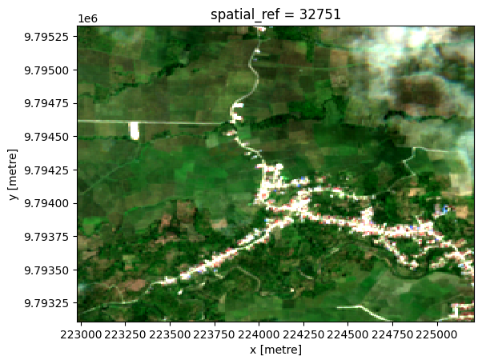

```python
ds_s2.mean(dim="time")[["red","green","blue"]].to_array().plot.imshow(robust=True);
```

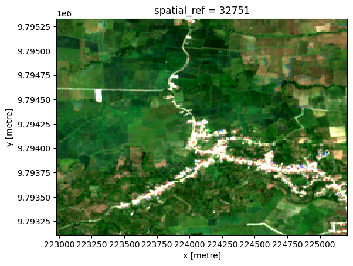

```python
ds_s2.median(dim="time")[["red","green","blue"]].to_array().plot.imshow(robust=True);
```

```python
ds_s2.mean(dim=["x","y"])
```

```
<xarray.Dataset>
Dimensions:      (time: 3)
Coordinates:
  * time         (time) datetime64[ns] 2022-02-28T02:28:06 ... 2022-04-24T02:...
    spatial_ref  int32 32751
Data variables:
    red          (time) float64 595.5 473.0 614.0
    green        (time) float64 762.9 645.2 709.3
    blue         (time) float64 587.3 410.5 466.4
    mask         (time) float64 4.207 4.115 4.218
```

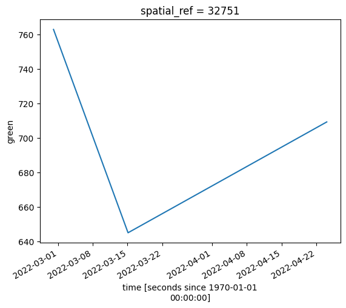

```python
ds_s2.mean(dim=["x","y"]).green.plot();
```

### Timeseries

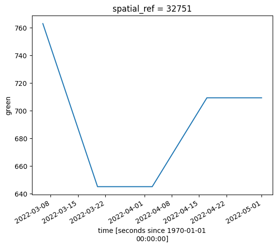

```python
ds_s2.resample(time='2W').nearest().mean(dim=["x","y"]).green.plot();
```

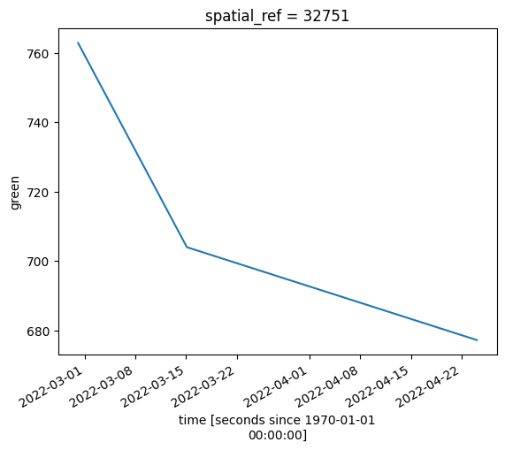

```python
ds_s2.rolling(time=2, min_periods=1).mean().mean(dim=["x","y"]).green.plot();
```

### Xarray and Pandas

```python
df = ds_s2.mean(dim=["x","y"]).green.to_dataframe()
```

```python
type(df)
```

```
pandas.core.frame.DataFrame
```

```python
df.to_csv('test.csv')
```

```python
dc.list_products()

#type(dc.list_products())
```

| name | name | description | license | default_crs | default_resolution |
| --- | --- | --- | --- | --- | --- |
| copernicus_dem_30 | copernicus_dem_30 | Copernicus 30m Digital Elevation Model (GLO-30) | None | None | None |
| landsat5_c2l2_sr | landsat5_c2l2_sr | Landsat 5 Collection 2 Level-2 Surface Reflect... | None | None | None |
| landsat5_c2l2_st | landsat5_c2l2_st | Landsat 5 Collection 2 Level-2 UTM Surface Tem... | CC-BY-4.0 | None | None |
| landsat7_c2l2_sr | landsat7_c2l2_sr | Landsat 7 USGS Collection 2 Surface Reflectanc... | None | None | None |
| landsat7_c2l2_st | landsat7_c2l2_st | Landsat 7 Collection 2 Level-2 UTM Surface Tem... | CC-BY-4.0 | None | None |
| landsat8_c2l1 | landsat8_c2l1 | Landsat 8 Collection 2 Level-1 (top of atmosph... | CC-BY-4.0 | None | None |
| landsat8_c2l2_sr | landsat8_c2l2_sr | Landsat 8 Collection 2 Surface Reflectance, pr... | None | None | None |
| landsat8_c2l2_st | landsat8_c2l2_st | Landsat 8 Collection 2 Level-2 UTM Surface Tem... | CC-BY-4.0 | None | None |
| landsat9_c2l1 | landsat9_c2l1 | Landsat 9 Collection 2 Level-1 (top of atmosph... | CC-BY-4.0 | None | None |
| landsat9_c2l2_sr | landsat9_c2l2_sr | Landsat 9 Collection 2 Surface Reflectance, pr... | CC-BY-4.0 | None | None |
| landsat9_c2l2_st | landsat9_c2l2_st | Landsat 9 Collection 2 Level-2 UTM Surface Tem... | CC-BY-4.0 | None | None |
| lpdaac_nasadem | lpdaac_nasadem | NASADEM Merged DEM Global 1 arc second V001 | None | None | None |
| nasa_aqua_l2_oc | nasa_aqua_l2_oc | NASA MODIS-Aqua L2 Ocean Color, regridded to W... | None | EPSG:4326 | (0.01, 0.01) |
| nasa_aqua_l2_sst | nasa_aqua_l2_sst | NASA MODIS-Aqua L2 Sea Surface Temperature, re... | None | EPSG:4326 | (0.01, 0.01) |
| s2_l2a | s2_l2a | Sentinel-2a and Sentinel-2b imagery, processed... | None | None | None |

#### Learn more about pandas and geopands

pandas: https://pandas.pydata.org/docs/user_guide/10min.html

geopandas: https://geopandas.org/en/stable/docs/user_guide.html

## Practice now

### Pick a dataset you are interested in.

If unsure, try Sentinel-2 for where you live or recently visited. If you have used Sentinel-2 through EASI or ODC, try another dataset.

### Explore loading the data and plotting.

### Try xarray operations

e.g.

- Select a timestamp to plot. Trying using .isel() and sel().
- Calculate mean values over time for each pixel and plot the result.
- Try a different calculation (e.g. sum, median) or try to apply the calculation on a different dimension and plot the results
- Resample the data to a monthly (or daily, quarterly) frequency and plot monthly mean values as a line plot
- Save the result

### Think about

- What did you try to achieve and what you've accomplished or learned?
- What type of data did you access? Why? E.g. what does this data measure?
- What else would you like to do with this dataset?